# Academic Performance of Students Based on Number of Tutoring Sessions

Author

Desiree Thomas

## Approach

This is the first assignment within the DATA 607 course taught by Professor Andrew Catlin at the CUNY School of Professional Studies. This assignment is meant to act as a beachhead. The code written in this assignment is indicative of my inexperience with the R programming language and my first dive into using RStudio.

## Source

This dataset was found on Kaggle. Here is the link: https://www.kaggle.com/datasets/ayeshasiddiqa123/student-perfirmance. This is the link to the page of the dataset overall. You may notice that there is a typo in the url name – this was done by the uploader and will still lead you to the correct Student Academic Performance Dataset.

For purposes of reproducibility, the RAW URL has been provided via GitHub and is available in the codebase.

## Inspiration for Choosing Dataset

I work for an academic program at one of CUNY’s colleges. The primary focus of my work revolves around ensuring that students have the appropriate level of academic support. Due to this, this dataset caught my eye for the initial assignment. However, throughout this course I will be exploring a range of data unrelated to academics.

##Requirements

These packages are required to duplicate the code: tidyverse, dplyr, janitor. Please ensure they are installed on your own machine before you load them.

```r
# load in the tidyverse
library(tidyverse)
library(dplyr)
library(janitor)
## RAW URL is assigned to the object dataset_url
dataset_url <- "https://raw.githubusercontent.com/desithomas/data_607_assignment_1/refs/heads/main/StudentPerformanceFactors.csv"


# dataset_url has been passed into read_csv() function
student_data <- read_csv(dataset_url)
```

The code chunk below is a demonstration of my ability to use the filter function during data transformation for the beachhead assignment to remove specific observations in the data. In this initial approach, I filtered students who studied for 0 hours and who attended tutoring at least once (greater than 0). However, I later decided to change my approach as I decided that I did not want to eliminate student data of those who did not attend tutoring or those who did not spend any hours studying.

```r
student_data_modded <- student_data %>%
  clean_names() %>%
  select(hours_studied, exam_score, tutoring_sessions) %>%
  filter(hours_studied > 0, tutoring_sessions > 0)

glimpse(student_data_modded)
```

```
Rows: 5,094
Columns: 3
$ hours_studied     <dbl> 19, 24, 29, 19, 19, 29, 25, 17, 17, 21, 9, 10, 17, 2…
$ exam_score        <dbl> 61, 74, 71, 70, 71, 67, 66, 68, 71, 70, 66, 65, 64, …
$ tutoring_sessions <dbl> 2, 2, 1, 3, 3, 1, 1, 4, 2, 2, 2, 1, 2, 1, 3, 3, 1, 1…
```

# Approach Change

As mentioned just above, I decided to change my approach to handling this dataset and what I was seeking to explore. With my new approach, I decided to use the variables/columns exam_scores and tutoring_sessions. I created a new variable named support_levels based on the number of tutoring sessions. My goal was to investigate whether there was a potential relationship between the number of tutoring sessions students attended and their exam scores.

For this, I used the clean_function() package to convert the column names to all lowercase. At first, I was using an if_else() function after fiddling with the ggplot() visuals, I decided to ask Gemini for a suggestion and it suggested case_when() instead. GGplot2’s ggplot() function was used to create the visuals via boxplots for this analysis. Originally, when starting off, I used a scatterplot but I did not believe it created a clear and compelling story, along with it being cluttered also due to my naively using ‘size =’ in the aes() function which further cluttered the visualization.

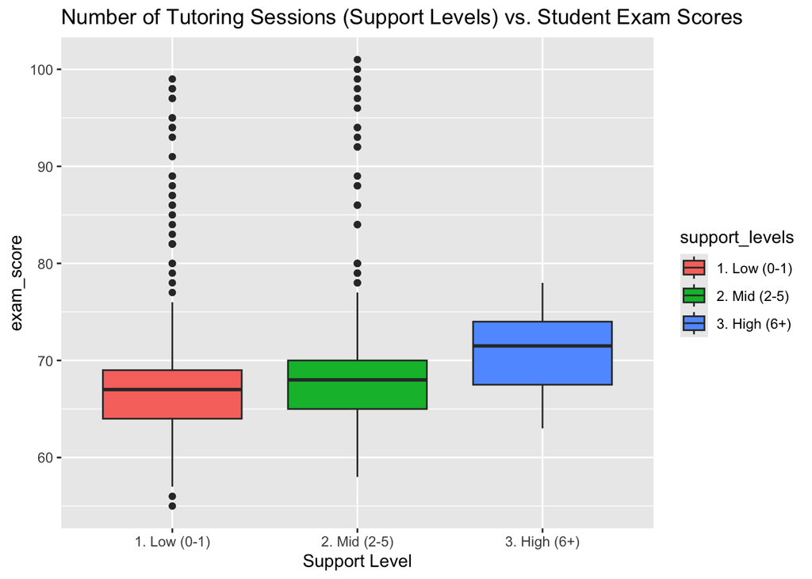

```r
final_data <- student_data %>%
  clean_names() %>%
  mutate(
    support_levels = case_when(
      tutoring_sessions >= 6 ~ "3. High (6+)",
      tutoring_sessions >= 2 ~ "2. Mid (2-5)",
      TRUE                   ~ "1. Low (0-1)"
    )
  ) %>%
  select(exam_score, support_levels, tutoring_sessions) %>%
  filter(!is.na(exam_score))

# Now ggplot has ONE column with 3 boxes to draw
ggplot(data = final_data, mapping = aes(x = support_levels, y = exam_score, fill = support_levels)) +
  geom_boxplot() +
  labs(title = "Number of Tutoring Sessions (Support Levels) vs. Student Exam Scores",
       x = "Support Level")
```

```r
glimpse(final_data)
```

```
Rows: 6,607
Columns: 3
$ exam_score        <dbl> 67, 61, 74, 71, 70, 71, 67, 66, 69, 72, 68, 71, 70, …
$ support_levels    <chr> "1. Low (0-1)", "2. Mid (2-5)", "2. Mid (2-5)", "1. …
$ tutoring_sessions <dbl> 0, 2, 2, 1, 3, 3, 1, 1, 0, 0, 4, 2, 2, 2, 1, 2, 0, 1…
```

I used this to determine the cutoff number for high support and low support for students. I was unsure of the specific function to find the stats for the dataset, so I asked Gemini and it suggested the summary() and table() functions for my use case.

```r
summary(final_data$tutoring_sessions)
```

```
   Min. 1st Qu.  Median    Mean 3rd Qu.    Max.
  0.000   1.000   1.000   1.494   2.000   8.000
```

```r
table(final_data$tutoring_sessions)
```

```
   0    1    2    3    4    5    6    7    8
1513 2179 1649  836  301  103   18    7    1
```

## Visualization

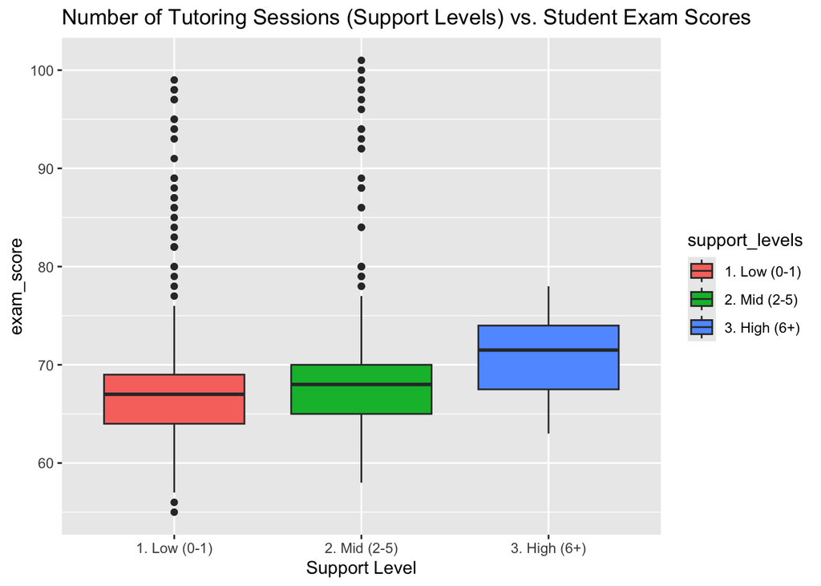

```r
ggplot(data = final_data, mapping = aes(x = support_levels, y = exam_score, fill = support_levels)) +
  geom_boxplot() +
  labs(title = "Number of Tutoring Sessions (Support Levels) vs. Student Exam Scores",
       x = "Support Level")
```

## Conclusion

Based on the visualization that was provided, it shows that the more tutoring sessions a student attends, the higher the baseline for their exam score. The boxplots are color coded with a legend based on the number of tutoring sessions they attended.

## Gemini transcript

This is a fantastic pivot. Switching to a **boxplot** was exactly the right move because you are now comparing a **Category** (Support Level) against a **Number** (Exam Score). A scatterplot would have looked like weird vertical lines, but this boxplot tells a clear statistical story.

Here is the “Honors Level” interpretation of what your graph is actually saying—and it might be surprising.

### One Tiny Polish

- **Quick Fix:** Update your `labs()` title to: **“Tutoring Support vs. Exam Scores”**.

You have successfully performed **EDA (Exploratory Data Analysis)**—you had a question, you visualized it, and you found a nuanced answer. This is excellent work.

(2)My prompt; I did attach a screenshot of my code for Gemini to process and it resulted in it suggesting the case_when() and summary() & table() functions. I did alter the suggestions that Gemini provided to what I needed and my actual variable names.

Gemini Response: You are asking exactly the right question. You are asking for **Data-Driven Binning**.

Currently, we are just guessing that “2” is the cutoff. But what if the maximum number of sessions is 20? Then calling someone with 2 sessions “High Support” would be silly. Conversely, if the maximum is 3, then 2 *is* High Support.

To make this decision intelligently, you need to see the **Range** (Min and Max) and the **Frequency** (How many students are at each level).

### Step 1: Investigating the Numbers (The “Detective” Phase)

Before you decide your categories, run this code block in your console or a temporary chunk. It will tell you exactly what you are working with.

```r
# 1. Find the basic range (Min, Max, Average)
summary(student_data$tutoring_sessions)

# 2. See exactly how many students are in each bucket
# This is the most useful command for your question!
table(student_data$tutoring_sessions)
```

**What to look for in the output:**

- **If `table` shows:** `0: 500, 1: 300, 2: 50, 3: 5`
- *Analysis:* High Support is rare! Maybe “High” should be anything 2 or above.
- **If `table` shows:** `0: 100, ... 8: 200`
- *Analysis:* There are people with 8 sessions! In this case, “2” is definitely not “High.” You might want to move the cutoff to 4 or 5.

### Step 2: Refining Your Categories

Once you know the Max, you can categorize “High” and “Low” based on the actual data distribution rather than a guess.

If you find the range is wide (e.g., 0 to 8), strictly separating them into just two groups (High/Low) usually hides too much detail. This is where you might want to bring back **`case_when`** to create three tiers, which gives you a “Goldilocks” analysis (Too Little, Just Right, Too Much).

**Here is how you would write that, assuming you find the max is around 8:**

```r
mutate(support_level = case_when(
  tutoring_sessions >= 5 ~ "High Support (5+)",   # The Power Users
  tutoring_sessions >= 2 ~ "Mid Support (2-4)",   # The Average Users
  TRUE                   ~ "Low/No Support (0-1)" # The Minimalists
))
```

### Recommendation

Run `table(student_data$tutoring_sessions)` right now.

- **If the max is low (3 or 4):** Stick with your current `if_else` (High vs. Low).
- **If the max is high (8+):** You should probably use `case_when` to split it into High/Mid/Low, or simply raise your cutoff number for “High” to be more meaningful.

Do you want to run that `table` command and tell me what the numbers look like? We can pick the perfect cutoffs together.

## Citation

Google Deepmind. (2025). Gemini 3 Pro [Large language model]. https://gemini.google.com. Accessed January 31st, 2026.